# ASPengdaDataset-WTvsT200M-JC

Kwame Forbes

10/3/2022

load Dependencies

```r
library(tidyr)
library("plyr")
library(devtools)
library(ggpubr)
```

```r
library("scrime")
library(pheatmap)
```

WT vs T200M JC only.

Variables

```r
IncLevelDifference.variable = 0.1
FDR.variable = 0.05
coverage = 50
```

WT vs T200M RI JC

```r
WTvT200M_ri_jc <- read.table("/nas/longleaf/home/kwamek/AS_Pengda/RMATS-WTvT200M/BAM/RI.MATS.JC.txt",header = T)
WTvT200M_ri_jc <- as.data.frame(WTvT200M_ri_jc)

AS = as.data.frame(rep("RI",dim(WTvT200M_ri_jc)[1]))
names(AS)[names(AS) == 'rep("RI", dim(WTvT200M_ri_jc)[1])'] <- "events"
WTvT200M_ri_jc = cbind(WTvT200M_ri_jc,AS)
Comparison = as.data.frame(rep("WTvT200M",dim(WTvT200M_ri_jc)[1]))
names(Comparison)[names(Comparison) == 'rep("WTvT200M", dim(WTvT200M_ri_jc)[1])'] <- "Comparison"
WTvT200M_ri_jc = cbind(WTvT200M_ri_jc,Comparison)

WTvT200M_ri_jc = unite(WTvT200M_ri_jc,"Position",c(4:11),sep = ":",remove = T)
WTvT200M_ri_jc$EVENT <- paste(WTvT200M_ri_jc$geneSymbol,WTvT200M_ri_jc$Position,sep = "_")
rownames(WTvT200M_ri_jc) <- WTvT200M_ri_jc$EVENT
WTvT200M_ri_jc <- subset(WTvT200M_ri_jc, select = -c(1:5))

WTvT200M_ri_jc <- separate(WTvT200M_ri_jc, col = IJC_SAMPLE_1, into = c("IJC_SAMPLE_WT1","IJC_SAMPLE_WT2","IJC_SAMPLE_WT3"),sep = ",",remove = T)
WTvT200M_ri_jc <- separate(WTvT200M_ri_jc, col = SJC_SAMPLE_1, into = c("SJC_SAMPLE_WT1","SJC_SAMPLE_WT2","SJC_SAMPLE_WT3"),sep = ",",remove = T)
WTvT200M_ri_jc <- separate(WTvT200M_ri_jc, col = IJC_SAMPLE_2, into = c("IJC_SAMPLE_T200M1","IJC_SAMPLE_T200M2","IJC_SAMPLE_T200M3"),sep = ",",remove = T)
WTvT200M_ri_jc <- separate(WTvT200M_ri_jc, col = SJC_SAMPLE_2, into = c("SJC_SAMPLE_T200M1","SJC_SAMPLE_T200M2","SJC_SAMPLE_T200M3"),sep = ",",remove = T)
WTvT200M_ri_jc[1:12] <- as.numeric(unlist(WTvT200M_ri_jc[1:12]))

WTvT200M_ri_jc <- separate(WTvT200M_ri_jc, col = IncLevel1, into = c("IncLevel_WT1","IncLevel_WT2","IncLevel_WT3"),sep = ",",remove = T)
WTvT200M_ri_jc <- separate(WTvT200M_ri_jc, col = IncLevel2, into = c("IncLevel_T200M1","IncLevel_T200M2","IncLevel_T200M3"),sep = ",",remove = T)
WTvT200M_ri_jc[17:22] <- as.numeric(unlist(WTvT200M_ri_jc[17:22]))
WTvT200M_ri_jc <- na.omit(WTvT200M_ri_jc)
```

Filtering WT vs T200M RI JC average reads, abs(IncLevelDifference), and FDR

```r
WTvT200M_ri_jc2 <- subset(WTvT200M_ri_jc,
                         apply(WTvT200M_ri_jc[c(1:6)], MARGIN =  1,mean)>=coverage
                         &apply(WTvT200M_ri_jc[c(7:12)], MARGIN =  1,mean)>=coverage)


WTvT200M_ri_jc3 <- subset(WTvT200M_ri_jc,
                         apply(WTvT200M_ri_jc[c(1,4)], MARGIN =  1,mean)>=coverage
                         &apply(WTvT200M_ri_jc[c(2,5)], MARGIN =  1,mean)>=coverage
                         &apply(WTvT200M_ri_jc[c(3,6)], MARGIN =  1,mean)>=coverage
                         &apply(WTvT200M_ri_jc[c(7,10)], MARGIN =  1,mean)>=coverage
                         &apply(WTvT200M_ri_jc[c(8,11)], MARGIN =  1,mean)>=coverage
                         &apply(WTvT200M_ri_jc[c(9,12)], MARGIN =  1,mean)>=coverage)

WTvT200M_ri_jc2 <- subset(WTvT200M_ri_jc2, abs(IncLevelDifference) >= IncLevelDifference.variable & FDR <= FDR.variable)
WTvT200M_ri_jc3 <- subset(WTvT200M_ri_jc3, abs(IncLevelDifference) >= IncLevelDifference.variable & FDR <= FDR.variable)
```

WT vs T200M SE JC

```r
WTvT200M_se_jc <- read.table("/nas/longleaf/home/kwamek/AS_Pengda/RMATS-WTvT200M/BAM/SE.MATS.JC.txt",header = T)
WTvT200M_se_jc <- as.data.frame(WTvT200M_se_jc)

AS = as.data.frame(rep("SE",dim(WTvT200M_se_jc)[1]))
names(AS)[names(AS) == 'rep("SE", dim(WTvT200M_se_jc)[1])'] <- "events"
WTvT200M_se_jc = cbind(WTvT200M_se_jc,AS)
Comparison = as.data.frame(rep("WTvT200M",dim(WTvT200M_se_jc)[1]))
names(Comparison)[names(Comparison) == 'rep("WTvT200M", dim(WTvT200M_se_jc)[1])'] <- "Comparison"
WTvT200M_se_jc = cbind(WTvT200M_se_jc,Comparison)

WTvT200M_se_jc = unite(WTvT200M_se_jc,"Position",c(4:11),sep = ":",remove = T)
WTvT200M_se_jc$EVENT <- paste(WTvT200M_se_jc$geneSymbol,WTvT200M_se_jc$Position,sep = "_")
rownames(WTvT200M_se_jc) <- WTvT200M_se_jc$EVENT
WTvT200M_se_jc <- subset(WTvT200M_se_jc, select = -c(1:5))

WTvT200M_se_jc <- separate(WTvT200M_se_jc, col = IJC_SAMPLE_1, into = c("IJC_SAMPLE_WT1","IJC_SAMPLE_WT2","IJC_SAMPLE_WT3"),sep = ",",remove = T)
WTvT200M_se_jc <- separate(WTvT200M_se_jc, col = SJC_SAMPLE_1, into = c("SJC_SAMPLE_WT1","SJC_SAMPLE_WT2","SJC_SAMPLE_WT3"),sep = ",",remove = T)
WTvT200M_se_jc <- separate(WTvT200M_se_jc, col = IJC_SAMPLE_2, into = c("IJC_SAMPLE_T200M1","IJC_SAMPLE_T200M2","IJC_SAMPLE_T200M3"),sep = ",",remove = T)
WTvT200M_se_jc <- separate(WTvT200M_se_jc, col = SJC_SAMPLE_2, into = c("SJC_SAMPLE_T200M1","SJC_SAMPLE_T200M2","SJC_SAMPLE_T200M3"),sep = ",",remove = T)
WTvT200M_se_jc[1:12] <- as.numeric(unlist(WTvT200M_se_jc[1:12]))

WTvT200M_se_jc <- separate(WTvT200M_se_jc, col = IncLevel1, into = c("IncLevel_WT1","IncLevel_WT2","IncLevel_WT3"),sep = ",",remove = T)
WTvT200M_se_jc <- separate(WTvT200M_se_jc, col = IncLevel2, into = c("IncLevel_T200M1","IncLevel_T200M2","IncLevel_T200M3"),sep = ",",remove = T)
WTvT200M_se_jc[17:22] <- as.numeric(unlist(WTvT200M_se_jc[17:22]))
WTvT200M_se_jc <- na.omit(WTvT200M_se_jc)
```

Filtering WT vs T200M SE JC by average reads, abs(IncLevelDifference), and FDR

```r
WTvT200M_se_jc2 <- subset(WTvT200M_se_jc,
                         apply(WTvT200M_se_jc[c(1:6)], MARGIN =  1,mean)>=coverage
                         &apply(WTvT200M_se_jc[c(7:12)], MARGIN =  1,mean)>=coverage)


WTvT200M_se_jc3 <- subset(WTvT200M_se_jc,
                         apply(WTvT200M_se_jc[c(1,4)], MARGIN =  1,mean)>=coverage
                         &apply(WTvT200M_se_jc[c(2,5)], MARGIN =  1,mean)>=coverage
                         &apply(WTvT200M_se_jc[c(3,6)], MARGIN =  1,mean)>=coverage
                         &apply(WTvT200M_se_jc[c(7,10)], MARGIN =  1,mean)>=coverage
                         &apply(WTvT200M_se_jc[c(8,11)], MARGIN =  1,mean)>=coverage
                         &apply(WTvT200M_se_jc[c(9,12)], MARGIN =  1,mean)>=coverage)

WTvT200M_se_jc2 <- subset(WTvT200M_se_jc2, abs(IncLevelDifference) >= IncLevelDifference.variable & FDR <= FDR.variable)
WTvT200M_se_jc3 <- subset(WTvT200M_se_jc3, abs(IncLevelDifference) >= IncLevelDifference.variable & FDR <= FDR.variable)
```

WT vs T200M A3SS JC

```r
WTvT200M_a3ss_jc <- read.table("/nas/longleaf/home/kwamek/AS_Pengda/RMATS-WTvT200M/BAM/A3SS.MATS.JC.txt",header = T)
WTvT200M_a3ss_jc <- as.data.frame(WTvT200M_a3ss_jc)

AS = as.data.frame(rep("A3SS",dim(WTvT200M_a3ss_jc)[1]))
names(AS)[names(AS) == 'rep("A3SS", dim(WTvT200M_a3ss_jc)[1])'] <- "events"
WTvT200M_a3ss_jc = cbind(WTvT200M_a3ss_jc,AS)
Comparison = as.data.frame(rep("WTvT200M",dim(WTvT200M_a3ss_jc)[1]))
names(Comparison)[names(Comparison) == 'rep("WTvT200M", dim(WTvT200M_a3ss_jc)[1])'] <- "Comparison"
WTvT200M_a3ss_jc = cbind(WTvT200M_a3ss_jc,Comparison)

WTvT200M_a3ss_jc = unite(WTvT200M_a3ss_jc,"Position",c(4:11),sep = ":",remove = T)
WTvT200M_a3ss_jc$EVENT <- paste(WTvT200M_a3ss_jc$geneSymbol,WTvT200M_a3ss_jc$Position,sep = "_")
rownames(WTvT200M_a3ss_jc) <- WTvT200M_a3ss_jc$EVENT
WTvT200M_a3ss_jc <- subset(WTvT200M_a3ss_jc, select = -c(1:5))

WTvT200M_a3ss_jc <- separate(WTvT200M_a3ss_jc, col = IJC_SAMPLE_1, into = c("IJC_SAMPLE_WT1","IJC_SAMPLE_WT2","IJC_SAMPLE_WT3"),sep = ",",remove = T)
WTvT200M_a3ss_jc <- separate(WTvT200M_a3ss_jc, col = SJC_SAMPLE_1, into = c("SJC_SAMPLE_WT1","SJC_SAMPLE_WT2","SJC_SAMPLE_WT3"),sep = ",",remove = T)
WTvT200M_a3ss_jc <- separate(WTvT200M_a3ss_jc, col = IJC_SAMPLE_2, into = c("IJC_SAMPLE_T200M1","IJC_SAMPLE_T200M2","IJC_SAMPLE_T200M3"),sep = ",",remove = T)
WTvT200M_a3ss_jc <- separate(WTvT200M_a3ss_jc, col = SJC_SAMPLE_2, into = c("SJC_SAMPLE_T200M1","SJC_SAMPLE_T200M2","SJC_SAMPLE_T200M3"),sep = ",",remove = T)
WTvT200M_a3ss_jc[1:12] <- as.numeric(unlist(WTvT200M_a3ss_jc[1:12]))

WTvT200M_a3ss_jc <- separate(WTvT200M_a3ss_jc, col = IncLevel1, into = c("IncLevel_WT1","IncLevel_WT2","IncLevel_WT3"),sep = ",",remove = T)
WTvT200M_a3ss_jc <- separate(WTvT200M_a3ss_jc, col = IncLevel2, into = c("IncLevel_T200M1","IncLevel_T200M2","IncLevel_T200M3"),sep = ",",remove = T)
WTvT200M_a3ss_jc[17:22] <- as.numeric(unlist(WTvT200M_a3ss_jc[17:22]))
WTvT200M_a3ss_jc <- na.omit(WTvT200M_a3ss_jc)
```

Filtering WT vs T200M A3SS JC by average reads, abs(IncLevelDifference), and FDR

```r
WTvT200M_a3ss_jc2 <- subset(WTvT200M_a3ss_jc,
                         apply(WTvT200M_a3ss_jc[c(1:6)], MARGIN =  1,mean)>=coverage
                         &apply(WTvT200M_a3ss_jc[c(7:12)], MARGIN =  1,mean)>=coverage)


WTvT200M_a3ss_jc3 <- subset(WTvT200M_a3ss_jc,
                         apply(WTvT200M_a3ss_jc[c(1,4)], MARGIN =  1,mean)>=coverage
                         &apply(WTvT200M_a3ss_jc[c(2,5)], MARGIN =  1,mean)>=coverage
                         &apply(WTvT200M_a3ss_jc[c(3,6)], MARGIN =  1,mean)>=coverage
                         &apply(WTvT200M_a3ss_jc[c(7,10)], MARGIN =  1,mean)>=coverage
                         &apply(WTvT200M_a3ss_jc[c(8,11)], MARGIN =  1,mean)>=coverage
                         &apply(WTvT200M_a3ss_jc[c(9,12)], MARGIN =  1,mean)>=coverage)

WTvT200M_a3ss_jc2 <- subset(WTvT200M_a3ss_jc2, abs(IncLevelDifference) >= IncLevelDifference.variable & FDR <= FDR.variable)
WTvT200M_a3ss_jc3 <- subset(WTvT200M_a3ss_jc3, abs(IncLevelDifference) >= IncLevelDifference.variable & FDR <= FDR.variable)
```

WT vs T200M A5SS JC

```r
WTvT200M_a5ss_jc <- read.table("/nas/longleaf/home/kwamek/AS_Pengda/RMATS-WTvT200M/BAM/A5SS.MATS.JC.txt",header = T)
WTvT200M_a5ss_jc <- as.data.frame(WTvT200M_a5ss_jc)

AS = as.data.frame(rep("A5SS",dim(WTvT200M_a5ss_jc)[1]))
names(AS)[names(AS) == 'rep("A5SS", dim(WTvT200M_a5ss_jc)[1])'] <- "events"
WTvT200M_a5ss_jc = cbind(WTvT200M_a5ss_jc,AS)
Comparison = as.data.frame(rep("WTvT200M",dim(WTvT200M_a5ss_jc)[1]))
names(Comparison)[names(Comparison) == 'rep("WTvT200M", dim(WTvT200M_a5ss_jc)[1])'] <- "Comparison"
WTvT200M_a5ss_jc = cbind(WTvT200M_a5ss_jc,Comparison)

WTvT200M_a5ss_jc = unite(WTvT200M_a5ss_jc,"Position",c(4:11),sep = ":",remove = T)
WTvT200M_a5ss_jc$EVENT <- paste(WTvT200M_a5ss_jc$geneSymbol,WTvT200M_a5ss_jc$Position,sep = "_")
rownames(WTvT200M_a5ss_jc) <- WTvT200M_a5ss_jc$EVENT
WTvT200M_a5ss_jc <- subset(WTvT200M_a5ss_jc, select = -c(1:5))

WTvT200M_a5ss_jc <- separate(WTvT200M_a5ss_jc, col = IJC_SAMPLE_1, into = c("IJC_SAMPLE_WT1","IJC_SAMPLE_WT2","IJC_SAMPLE_WT3"),sep = ",",remove = T)
WTvT200M_a5ss_jc <- separate(WTvT200M_a5ss_jc, col = SJC_SAMPLE_1, into = c("SJC_SAMPLE_WT1","SJC_SAMPLE_WT2","SJC_SAMPLE_WT3"),sep = ",",remove = T)
WTvT200M_a5ss_jc <- separate(WTvT200M_a5ss_jc, col = IJC_SAMPLE_2, into = c("IJC_SAMPLE_T200M1","IJC_SAMPLE_T200M2","IJC_SAMPLE_T200M3"),sep = ",",remove = T)
WTvT200M_a5ss_jc <- separate(WTvT200M_a5ss_jc, col = SJC_SAMPLE_2, into = c("SJC_SAMPLE_T200M1","SJC_SAMPLE_T200M2","SJC_SAMPLE_T200M3"),sep = ",",remove = T)
WTvT200M_a5ss_jc[1:12] <- as.numeric(unlist(WTvT200M_a5ss_jc[1:12]))

WTvT200M_a5ss_jc <- separate(WTvT200M_a5ss_jc, col = IncLevel1, into = c("IncLevel_WT1","IncLevel_WT2","IncLevel_WT3"),sep = ",",remove = T)
WTvT200M_a5ss_jc <- separate(WTvT200M_a5ss_jc, col = IncLevel2, into = c("IncLevel_T200M1","IncLevel_T200M2","IncLevel_T200M3"),sep = ",",remove = T)
WTvT200M_a5ss_jc[17:22] <- as.numeric(unlist(WTvT200M_a5ss_jc[17:22]))
WTvT200M_a5ss_jc <- na.omit(WTvT200M_a5ss_jc)
```

Filtering WT vs T200M A5SS JC by average reads, abs(IncLevelDifference), and FDR

```r
WTvT200M_a5ss_jc2 <- subset(WTvT200M_a5ss_jc,
                         apply(WTvT200M_a5ss_jc[c(1:6)], MARGIN =  1,mean)>=coverage
                         &apply(WTvT200M_a5ss_jc[c(7:12)], MARGIN =  1,mean)>=coverage)


WTvT200M_a5ss_jc3 <- subset(WTvT200M_a5ss_jc,
                         apply(WTvT200M_a5ss_jc[c(1,4)], MARGIN =  1,mean)>=coverage
                         &apply(WTvT200M_a5ss_jc[c(2,5)], MARGIN =  1,mean)>=coverage
                         &apply(WTvT200M_a5ss_jc[c(3,6)], MARGIN =  1,mean)>=coverage
                         &apply(WTvT200M_a5ss_jc[c(7,10)], MARGIN =  1,mean)>=coverage
                         &apply(WTvT200M_a5ss_jc[c(8,11)], MARGIN =  1,mean)>=coverage
                         &apply(WTvT200M_a5ss_jc[c(9,12)], MARGIN =  1,mean)>=coverage)

WTvT200M_a5ss_jc2 <- subset(WTvT200M_a5ss_jc2, abs(IncLevelDifference) >= IncLevelDifference.variable & FDR <= FDR.variable)
WTvT200M_a5ss_jc3 <- subset(WTvT200M_a5ss_jc3, abs(IncLevelDifference) >= IncLevelDifference.variable & FDR <= FDR.variable)
```

WT vs T200M MXE JC

```r
WTvT200M_mxe_jc <- read.table("/nas/longleaf/home/kwamek/AS_Pengda/RMATS-WTvT200M/BAM/MXE.MATS.JC.txt",header = T)
WTvT200M_mxe_jc <- as.data.frame(WTvT200M_mxe_jc)

AS = as.data.frame(rep("MXE",dim(WTvT200M_mxe_jc)[1]))
names(AS)[names(AS) == 'rep("MXE", dim(WTvT200M_mxe_jc)[1])'] <- "events"
WTvT200M_mxe_jc = cbind(WTvT200M_mxe_jc,AS)
Comparison = as.data.frame(rep("WTvT200M",dim(WTvT200M_mxe_jc)[1]))
names(Comparison)[names(Comparison) == 'rep("WTvT200M", dim(WTvT200M_mxe_jc)[1])'] <- "Comparison"
WTvT200M_mxe_jc = cbind(WTvT200M_mxe_jc,Comparison)

WTvT200M_mxe_jc = unite(WTvT200M_mxe_jc,"Position",c(4:13),sep = ":",remove = T)
WTvT200M_mxe_jc$EVENT <- paste(WTvT200M_mxe_jc$geneSymbol,WTvT200M_mxe_jc$Position,sep = "_")
rownames(WTvT200M_mxe_jc) <- WTvT200M_mxe_jc$EVENT
WTvT200M_mxe_jc <- subset(WTvT200M_mxe_jc, select = -c(1:5))

WTvT200M_mxe_jc <- separate(WTvT200M_mxe_jc, col = IJC_SAMPLE_1, into = c("IJC_SAMPLE_WT1","IJC_SAMPLE_WT2","IJC_SAMPLE_WT3"),sep = ",",remove = T)
WTvT200M_mxe_jc <- separate(WTvT200M_mxe_jc, col = SJC_SAMPLE_1, into = c("SJC_SAMPLE_WT1","SJC_SAMPLE_WT2","SJC_SAMPLE_WT3"),sep = ",",remove = T)
WTvT200M_mxe_jc <- separate(WTvT200M_mxe_jc, col = IJC_SAMPLE_2, into = c("IJC_SAMPLE_T200M1","IJC_SAMPLE_T200M2","IJC_SAMPLE_T200M3"),sep = ",",remove = T)
WTvT200M_mxe_jc <- separate(WTvT200M_mxe_jc, col = SJC_SAMPLE_2, into = c("SJC_SAMPLE_T200M1","SJC_SAMPLE_T200M2","SJC_SAMPLE_T200M3"),sep = ",",remove = T)
WTvT200M_mxe_jc[1:12] <- as.numeric(unlist(WTvT200M_mxe_jc[1:12]))

WTvT200M_mxe_jc <- separate(WTvT200M_mxe_jc, col = IncLevel1, into = c("IncLevel_WT1","IncLevel_WT2","IncLevel_WT3"),sep = ",",remove = T)
WTvT200M_mxe_jc <- separate(WTvT200M_mxe_jc, col = IncLevel2, into = c("IncLevel_T200M1","IncLevel_T200M2","IncLevel_T200M3"),sep = ",",remove = T)
WTvT200M_mxe_jc[17:22] <- as.numeric(unlist(WTvT200M_mxe_jc[17:22]))
WTvT200M_mxe_jc <- na.omit(WTvT200M_mxe_jc)
```

Filtering WT vs T200M MXE JC by average reads, abs(IncLevelDifference), and FDR

```r
WTvT200M_mxe_jc2 <- subset(WTvT200M_mxe_jc,
                         apply(WTvT200M_mxe_jc[c(1:6)], MARGIN =  1,mean)>=coverage
                         &apply(WTvT200M_mxe_jc[c(7:12)], MARGIN =  1,mean)>=coverage)


WTvT200M_mxe_jc3 <- subset(WTvT200M_mxe_jc,
                         apply(WTvT200M_mxe_jc[c(1,4)], MARGIN =  1,mean)>=coverage
                         &apply(WTvT200M_mxe_jc[c(2,5)], MARGIN =  1,mean)>=coverage
                         &apply(WTvT200M_mxe_jc[c(3,6)], MARGIN =  1,mean)>=coverage
                         &apply(WTvT200M_mxe_jc[c(7,10)], MARGIN =  1,mean)>=coverage
                         &apply(WTvT200M_mxe_jc[c(8,11)], MARGIN =  1,mean)>=coverage
                         &apply(WTvT200M_mxe_jc[c(9,12)], MARGIN =  1,mean)>=coverage)

WTvT200M_mxe_jc2 <- subset(WTvT200M_mxe_jc2, abs(IncLevelDifference) >= IncLevelDifference.variable & FDR <= FDR.variable)
WTvT200M_mxe_jc3 <- subset(WTvT200M_mxe_jc3, abs(IncLevelDifference) >= IncLevelDifference.variable & FDR <= FDR.variable)
```

Combining ALL AS EVENTS and those filtered(2,3)

```r
WTvT200M_jc <- rbind(WTvT200M_ri_jc,WTvT200M_se_jc,WTvT200M_a3ss_jc,WTvT200M_a5ss_jc,WTvT200M_mxe_jc)
rownames(WTvT200M_jc) <- rownames(WTvT200M_jc$EVENT)
colnames(WTvT200M_jc)<-gsub("IncLevel_","PSI_",colnames(WTvT200M_jc))
WTvT200M_jc$Event <-ifelse(WTvT200M_jc$IncLevelDifference > 0,"WT","T200M")


WTvT200M_jc2 <- rbind(WTvT200M_ri_jc2,WTvT200M_se_jc2,WTvT200M_a3ss_jc2,WTvT200M_a5ss_jc2,WTvT200M_mxe_jc2)
rownames(WTvT200M_jc2) <- rownames(WTvT200M_jc2$EVENT)
colnames(WTvT200M_jc2)<-gsub("IncLevel_","PSI_",colnames(WTvT200M_jc2))
WTvT200M_jc2$Event <-ifelse(WTvT200M_jc2$IncLevelDifference > 0,"WT","T200M")



WTvT200M_jc3 <- rbind(WTvT200M_ri_jc3,WTvT200M_se_jc3,WTvT200M_a3ss_jc3,WTvT200M_a5ss_jc3,WTvT200M_mxe_jc3)
rownames(WTvT200M_jc3) <- rownames(WTvT200M_jc3$EVENT)
colnames(WTvT200M_jc3)<-gsub("IncLevel_","PSI_",colnames(WTvT200M_jc3))
WTvT200M_jc3$Event <-ifelse(WTvT200M_jc3$IncLevelDifference > 0,"WT","T200M")



# write.csv(WTvT200M_jc,"WTvsT200M-50counts-filtered.csv")
# write.csv(WTvT200M_ri_jc,"WTvsT200M-RI-50counts-filtered.csv")
```

PheatMap all events

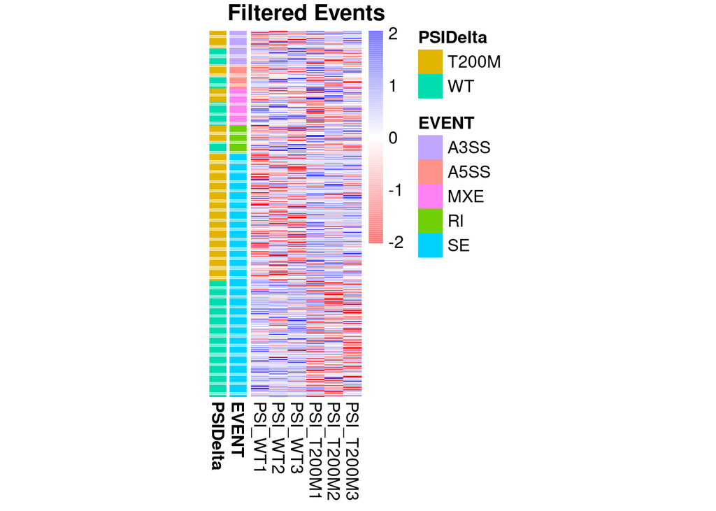

```r
Anno <- data.frame(EVENT = WTvT200M_jc$events,PSIDelta = WTvT200M_jc$Event)

rownames(WTvT200M_jc) <- WTvT200M_jc$EVENT
rownames(Anno) <- WTvT200M_jc$EVENT

WTvT200M_jc <- WTvT200M_jc[order(WTvT200M_jc$events,WTvT200M_jc$Event),]

pheatmap(WTvT200M_jc[17:22], cluster_rows=F, show_rownames=F,
         cluster_cols=F, main = "Filtered Events",border_color = F,
         annotation_row = Anno,scale = "row",
         color=colorRampPalette(c("red", "white", "blue"))(73000),
         fontsize = 12,cellwidth = 13)
```

PheatMap filtered by avg reads across conditions

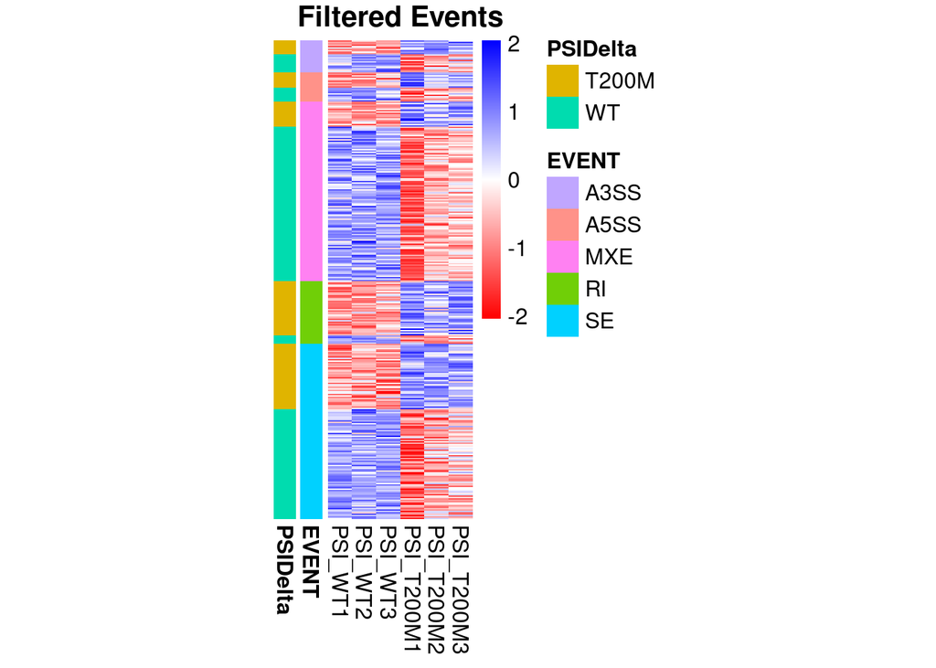

```r
Anno <- data.frame(EVENT = WTvT200M_jc2$events,PSIDelta = WTvT200M_jc2$Event)

rownames(WTvT200M_jc2) <- WTvT200M_jc2$EVENT
rownames(Anno) <- WTvT200M_jc2$EVENT

WTvT200M_jc2 <- WTvT200M_jc2[order(WTvT200M_jc2$events,WTvT200M_jc2$Event),]

pheatmap(WTvT200M_jc2[17:22], cluster_rows=F, show_rownames=F,
         cluster_cols=F, main = "Filtered Events",border_color = F,
         annotation_row = Anno,scale = "row",
         color=colorRampPalette(c("red", "white", "blue"))(400),
         fontsize = 12,cellwidth = 13)
```

PheatMap filtered by avg reads across reps

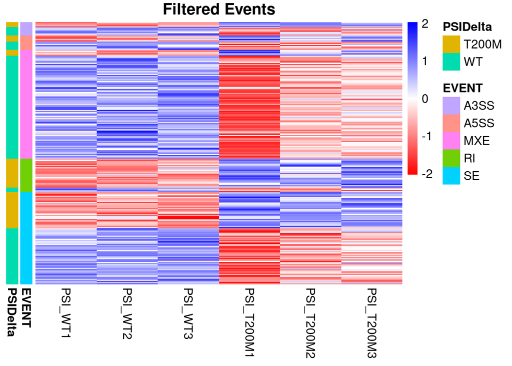

```r
Anno <- data.frame(EVENT = WTvT200M_jc3$events,PSIDelta = WTvT200M_jc3$Event)

rownames(WTvT200M_jc3) <- WTvT200M_jc3$EVENT
rownames(Anno) <- WTvT200M_jc3$EVENT

WTvT200M_jc3 <- WTvT200M_jc3[order(WTvT200M_jc3$events,WTvT200M_jc3$Event),]

pheatmap(WTvT200M_jc3[17:22], cluster_rows=F, show_rownames=F,
         cluster_cols=F, main = "Filtered Events",border_color = F,
         annotation_row = Anno,scale = "row",
         color=colorRampPalette(c("red", "white", "blue"))(219),
         fontsize = 12)
```

Plots for all AS events

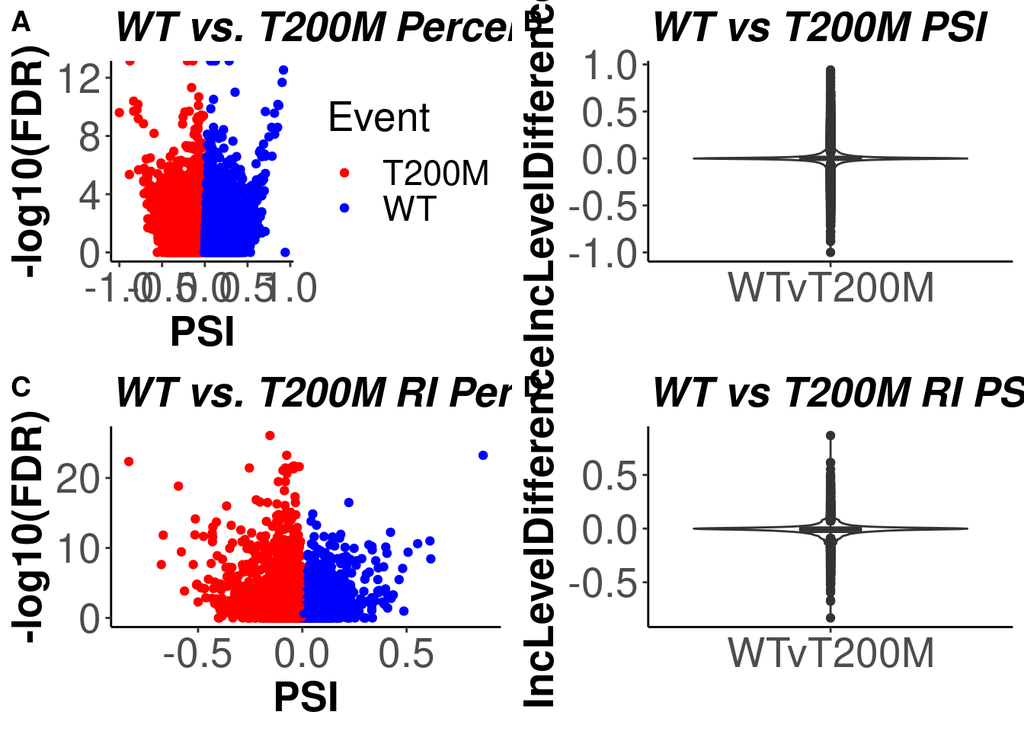

```r
a <- ggplot(data = WTvT200M_jc,mapping=
              aes(x =IncLevelDifference,y =-log10(FDR),color=Event))+ theme_classic() + geom_point() +
   ggtitle("WT vs. T200M Percent Spliced In") +xlab("PSI") + ylab("-log10(FDR)") + scale_color_manual(values=c("red", "blue"))
a <- a + theme(plot.title = element_text(color="black", size=20, face="bold.italic"),
         axis.title.x = element_text(color="black", size=20, face="bold"),
         axis.title.y = element_text(color="black", size=20, face="bold"),
         axis.text = element_text(size = 20),
         legend.text = element_text(size=17),
         legend.title = element_text(size=20))

b <- ggplot(WTvT200M_jc, aes("WTvT200M", y=IncLevelDifference)) +
   theme_classic()+ ggtitle("WT vs T200M PSI") + labs( y = "IncLevelDifference", x = " ") + geom_violin()

b <- b + geom_boxplot(width=0.2)+
  theme(plot.title = element_text(color="black", size=20, face="bold.italic"),
         axis.title.x = element_text(color="black", size=20, face="bold"),
         axis.title.y = element_text(color="black", size=20, face="bold"),
         axis.text = element_text(size = 20))

c <- ggplot(data = WTvT200M_ri_jc,mapping=
              aes(IncLevelDifference,-log(FDR)))+ theme_classic() + geom_point(color = ifelse(WTvT200M_ri_jc$IncLevelDifference > 0 ,"blue","red")) +
  theme_classic()+ ggtitle("WT vs. T200M RI Percent Spliced In") +xlab("PSI") + ylab("-log10(FDR)")
c <- c + theme(plot.title = element_text(color="black", size=20, face="bold.italic"),
         axis.title.x = element_text(color="black", size=20, face="bold"),
         axis.title.y = element_text(color="black", size=20, face="bold"),
         axis.text = element_text(size = 20),
         legend.text = element_text(size=17),
         legend.title = element_text(size=20))


d <- ggplot(WTvT200M_ri_jc, aes(x="WTvT200M", y=IncLevelDifference)) +
   theme_classic()+ ggtitle("WT vs T200M RI PSI") + labs( y = "IncLevelDifference", x = " ") + geom_violin()
d <- d + geom_boxplot(width=0.2)+
  theme(plot.title = element_text(color="black", size=20, face="bold.italic"),
         axis.title.x = element_text(color="black", size=20, face="bold"),
         axis.title.y = element_text(color="black", size=20, face="bold"),
         axis.text = element_text(size = 20))




all_events <- ggarrange(a,b,c,d,
          labels = c("A", "B", "C", "D"),
          ncol = 2, nrow = 2)

all_events
```

Plots for AS events filtered by avg reads across conditions

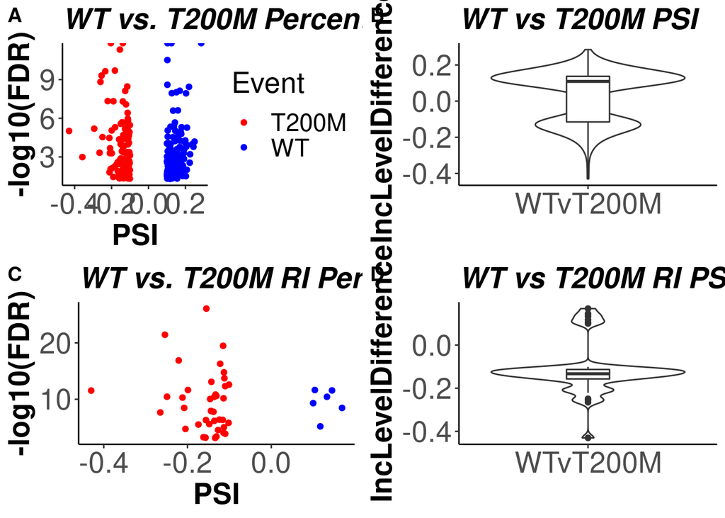

```r
a <- ggplot(data = WTvT200M_jc2,mapping=
              aes(x =IncLevelDifference,y =-log10(FDR),color=Event))+ theme_classic() + geom_point() +
   ggtitle("WT vs. T200M Percent Spliced In") +xlab("PSI") + ylab("-log10(FDR)") + scale_color_manual(values=c("red", "blue"))
a <- a + theme(plot.title = element_text(color="black", size=20, face="bold.italic"),
         axis.title.x = element_text(color="black", size=20, face="bold"),
         axis.title.y = element_text(color="black", size=20, face="bold"),
         axis.text = element_text(size = 20),
         legend.text = element_text(size=17),
         legend.title = element_text(size=20))

b <- ggplot(WTvT200M_jc2, aes("WTvT200M", y=IncLevelDifference)) +
   theme_classic()+ ggtitle("WT vs T200M PSI") + labs( y = "IncLevelDifference", x = " ") + geom_violin()

b <- b + geom_boxplot(width=0.2)+
  theme(plot.title = element_text(color="black", size=20, face="bold.italic"),
         axis.title.x = element_text(color="black", size=20, face="bold"),
         axis.title.y = element_text(color="black", size=20, face="bold"),
         axis.text = element_text(size = 20))

c <- ggplot(data = WTvT200M_ri_jc2,mapping=
              aes(IncLevelDifference,-log(FDR)))+ theme_classic() + geom_point(color = ifelse(WTvT200M_ri_jc2$IncLevelDifference > 0 ,"blue","red")) +
  theme_classic()+ ggtitle("WT vs. T200M RI Percent Spliced In") +xlab("PSI") + ylab("-log10(FDR)")
c <- c + theme(plot.title = element_text(color="black", size=20, face="bold.italic"),
         axis.title.x = element_text(color="black", size=20, face="bold"),
         axis.title.y = element_text(color="black", size=20, face="bold"),
         axis.text = element_text(size = 20),
         legend.text = element_text(size=17),
         legend.title = element_text(size=20))


d <- ggplot(WTvT200M_ri_jc2, aes(x="WTvT200M", y=IncLevelDifference)) +
   theme_classic()+ ggtitle("WT vs T200M RI PSI") + labs( y = "IncLevelDifference", x = " ") + geom_violin()
d <- d + geom_boxplot(width=0.2)+
  theme(plot.title = element_text(color="black", size=20, face="bold.italic"),
         axis.title.x = element_text(color="black", size=20, face="bold"),
         axis.title.y = element_text(color="black", size=20, face="bold"),
         axis.text = element_text(size = 20))




across_conditions <- ggarrange(a,b,c,d,
          labels = c("A", "B", "C", "D"),
          ncol = 2, nrow = 2)

across_conditions
```

Plots for AS events filtered by avg reads across reps

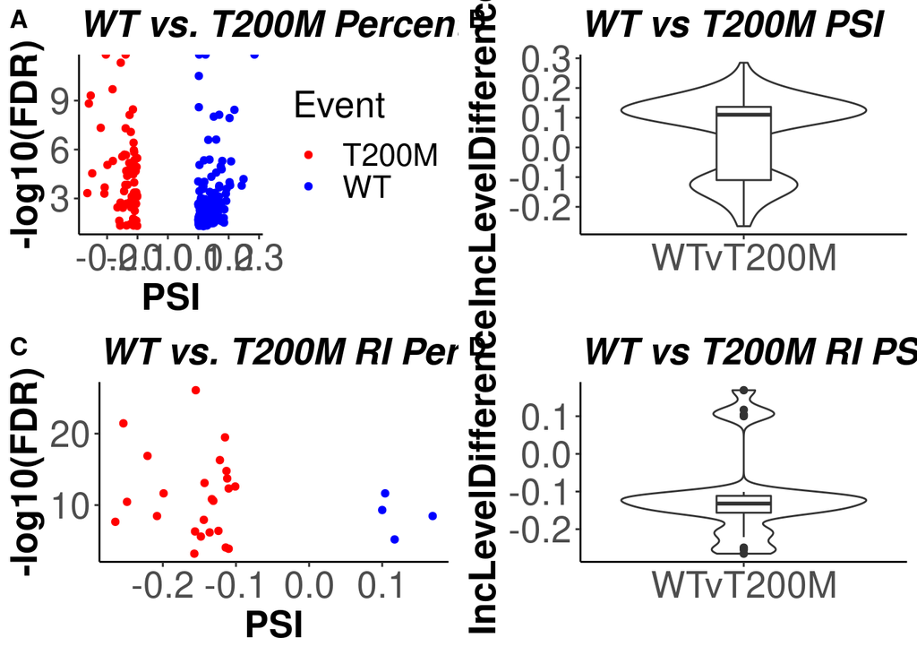

```r
a <- ggplot(data = WTvT200M_jc3,mapping=
              aes(x =IncLevelDifference,y =-log10(FDR),color=Event))+ theme_classic() + geom_point() +
   ggtitle("WT vs. T200M Percent Spliced In") +xlab("PSI") + ylab("-log10(FDR)") + scale_color_manual(values=c("red", "blue"))
a <- a + theme(plot.title = element_text(color="black", size=20, face="bold.italic"),
         axis.title.x = element_text(color="black", size=20, face="bold"),
         axis.title.y = element_text(color="black", size=20, face="bold"),
         axis.text = element_text(size = 20),
         legend.text = element_text(size=17),
         legend.title = element_text(size=20))

b <- ggplot(WTvT200M_jc3, aes("WTvT200M", y=IncLevelDifference)) +
   theme_classic()+ ggtitle("WT vs T200M PSI") + labs( y = "IncLevelDifference", x = " ") + geom_violin()

b <- b + geom_boxplot(width=0.2)+
  theme(plot.title = element_text(color="black", size=20, face="bold.italic"),
         axis.title.x = element_text(color="black", size=20, face="bold"),
         axis.title.y = element_text(color="black", size=20, face="bold"),
         axis.text = element_text(size = 20))

c <- ggplot(data = WTvT200M_ri_jc3,mapping=
              aes(IncLevelDifference,-log(FDR)))+ theme_classic() + geom_point(color = ifelse(WTvT200M_ri_jc3$IncLevelDifference > 0 ,"blue","red")) +
  theme_classic()+ ggtitle("WT vs. T200M RI Percent Spliced In") +xlab("PSI") + ylab("-log10(FDR)")
c <- c + theme(plot.title = element_text(color="black", size=20, face="bold.italic"),
         axis.title.x = element_text(color="black", size=20, face="bold"),
         axis.title.y = element_text(color="black", size=20, face="bold"),
         axis.text = element_text(size = 20),
         legend.text = element_text(size=17),
         legend.title = element_text(size=20))


d <- ggplot(WTvT200M_ri_jc3, aes(x="WTvT200M", y=IncLevelDifference)) +
   theme_classic()+ ggtitle("WT vs T200M RI PSI") + labs( y = "IncLevelDifference", x = " ") + geom_violin()
d <- d + geom_boxplot(width=0.2)+
  theme(plot.title = element_text(color="black", size=20, face="bold.italic"),
         axis.title.x = element_text(color="black", size=20, face="bold"),
         axis.title.y = element_text(color="black", size=20, face="bold"),
         axis.text = element_text(size = 20))




across_reps <- ggarrange(a,b,c,d,
          labels = c("A", "B", "C", "D"),
          ncol = 2, nrow = 2)

across_reps
```

looking at specific genes

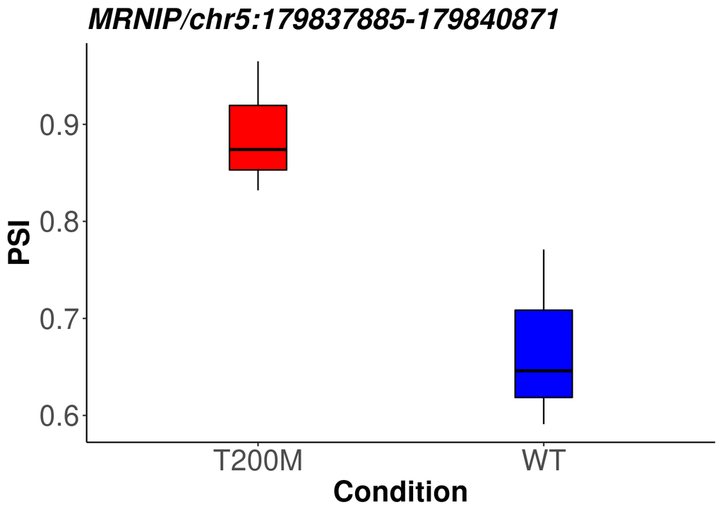

```r
WTvT200M_GENE <- subset(WTvT200M_ri_jc,EVENT=='MRNIP_chr5:-:179837275:179840959:179837275:179837885:179840871:179840959')

condition <- c('WT','WT','WT','T200M','T200M','T200M')
PSI <- c(WTvT200M_GENE$IncLevel_WT1,WTvT200M_GENE$IncLevel_WT2,WTvT200M_GENE$IncLevel_WT3,WTvT200M_GENE$IncLevel_T200M1,WTvT200M_GENE$IncLevel_T200M2,WTvT200M_GENE$IncLevel_T200M3)
gene_plot <- cbind.data.frame(condition,PSI)
d <- ggplot(gene_plot, aes(x=condition, y=PSI)) +
   theme_classic()+ ggtitle('MRNIP/chr5:179837885-179840871') + labs(x ='Condition',y = "PSI")
d <- d + geom_boxplot(width=0.2, fill = c('Red','Blue'),color = 'Black' )+
  theme(plot.title = element_text(color="black", size=20, face="bold.italic"),
         axis.title.x = element_text(color="black", size=20, face="bold"),
         axis.title.y = element_text(color="black", size=20, face="bold"),
         axis.text = element_text(size = 20))
d
```